신록예찬's 블로그

# (노트) Pytorch CNN (MNIST 3,7)

Oct 21, 2021 • 신록예찬 • 9 min read

빅데이터분석

### import

```python
import torch
from fastai.vision.all import *
```

```python
import graphviz
```

```python
def gv(s): return graphviz.Source('digraph G{ rankdir="LR"' + s + '; }')
```

### data

`-` download data

```python
path = untar_data(URLs.MNIST_SAMPLE)
```

```python
path.ls()
```

```
(#3) [Path('/home/cgb2/.fastai/data/mnist_sample/labels.csv'),Path('/home/cgb2/.fastai/data/mnist_sample/valid'),Path('/home/cgb2/.fastai/data/mnist_sample/train')]
```

`-` list

```python
threes=(path/'train'/'3').ls()
sevens=(path/'train'/'7').ls()
```

`-` list $\to$ image

```python
Image.open(threes[0])
```

[output not shown]

`-` image $\to$ tensor

```python
tensor(Image.open(threes[0]))
```

```
tensor([[  0,   0,   0,   0,   0,   0,   0,   0,   0,   0,   0,   0,   0,   0,
           0,   0,   0,   0,   0,   0,   0,   0,   0,   0,   0,   0,   0,   0],
        [  0,   0,   0,   0,   0,   0,   0,   0,   0,   0,   0,   0,   0,   0,
           0,   0,   0,   0,   0,   0,   0,   0,   0,   0,   0,   0,   0,   0],
        [  0,   0,   0,   0,   0,   0,   0,   0,   0,   0,   0,   0,   0,   0,
           0,   0,   0,   0,   0,   0,   0,   0,   0,   0,   0,   0,   0,   0],
        [  0,   0,   0,   0,   0,   0,   0,   0,   0,   0,   0,   0,   0,   0,
           0,   0,   0,   0,   0,   0,   0,   0,   0,   0,   0,   0,   0,   0],
        [  0,   0,   0,   0,   0,   0,   0,   0,   0,   0,   0,   0,   0,   0,
           0,   0,   0,   0,   0,   0,   0,   0,   0,   0,   0,   0,   0,   0],
        [  0,   0,   0,   0,   0,   0,   0,   0,   0,   5,  70, 128, 200, 217,
         183, 174,  36,   0,   0,   0,   0,   0,   0,   0,   0,   0,   0,   0],
        [  0,   0,   0,   0,   0,   0,   0,  14, 123, 209, 254, 254, 254, 254,
         254, 254, 228,  38,   0,   0,   0,   0,   0,   0,   0,   0,   0,   0],
        [  0,   0,   0,   0,   0,   6,  94, 230, 254, 254, 254, 239, 235, 254,
         254, 254, 254, 219,   9,   0,   0,   0,   0,   0,   0,   0,   0,   0],
        [  0,   0,   0,   0,  13, 173, 254, 254, 241, 179,  95,  25,  21,  44,
          65, 205, 254, 254,  61,   0,   0,   0,   0,   0,   0,   0,   0,   0],
        [  0,   0,   0,   0,   4,  81, 194, 174,  55,   0,   0,   0,   0,   0,
           0, 158, 254, 254, 131,   0,   0,   0,   0,   0,   0,   0,   0,   0],
        [  0,   0,   0,   0,   0,   0,   0,   0,   0,   0,   0,   0,   0,   0,
           0,  84, 254, 254, 216,   0,   0,   0,   0,   0,   0,   0,   0,   0],
        [  0,   0,   0,   0,   0,   0,   0,   0,   0,   0,   0,   0,   0,   0,
           0, 156, 254, 254, 143,   0,   0,   0,   0,   0,   0,   0,   0,   0],
        [  0,   0,   0,   0,   0,   0,   0,   0,   0,   0,   0,   0,   0,   0,
           0, 158, 254, 254,  85,   0,   0,   0,   0,   0,   0,   0,   0,   0],
        [  0,   0,   0,   0,   0,   0,   0,   0,   0,   0,   0,   0,   0,   0,
           0, 193, 254, 252,  54,   0,   0,   0,   0,   0,   0,   0,   0,   0],
        [  0,   0,   0,   0,   0,   0,   0,   0,   0,   0,   0,   0,   0,   0,
          11, 242, 254, 182,   0,   0,   0,   0,   0,   0,   0,   0,   0,   0],
        [  0,   0,   0,   0,   0,   0,   0,   0,   0,   0,   0,   0,   0,  28,
         181, 254, 254, 161,  13,   0,   0,   0,   0,   0,   0,   0,   0,   0],
        [  0,   0,   0,   0,   0,   0,   0,   0,   0,   0,   0,  63, 184, 241,
         254, 254, 254, 254, 197,  49,   0,   0,   0,   0,   0,   0,   0,   0],
        [  0,   0,   0,   0,   0,   0,   0,   0,   0,   0,   0, 110, 254, 254,
         254, 254, 254, 254, 254, 233,  23,   0,   0,   0,   0,   0,   0,   0],
        [  0,   0,   0,   0,   0,   0,   0,   0,   0,   0,   0,  11, 124, 165,
         144,  60, 140, 252, 254, 254, 119,   0,   0,   0,   0,   0,   0,   0],
        [  0,   0,   0,   0,   0,   0,   0,   0,   0,   0,   0,   0,   0,   0,
           0,   0,   0, 119, 254, 254, 220,  10,   0,   0,   0,   0,   0,   0],
        [  0,   0,   0,   0,   0,   0,   0,   0,   0,   0,  21,   0,   0,   0,
           0,   0,   0,  21, 254, 254, 254,  24,   0,   0,   0,   0,   0,   0],
        [  0,   0,   0,   0,   0,   0,   0,   0,   0,  84, 237,  67,   0,   0,
           0,   0,   0,  21, 254, 254, 254,  24,   0,   0,   0,   0,   0,   0],
        [  0,   0,   0,   0,   0,   0,   0,   0,   0, 123, 254, 204,  65,   0,
           0,   0,   0, 134, 254, 254, 169,   4,   0,   0,   0,   0,   0,   0],
        [  0,   0,   0,   0,   0,   0,   0,   0,   0,  10, 210, 254, 251, 231,
         159,  99, 178, 248, 254, 220,  27,   0,   0,   0,   0,   0,   0,   0],
        [  0,   0,   0,   0,   0,   0,   0,   0,   0,   0,  76, 254, 255, 254,
         254, 254, 254, 254, 182,  22,   0,   0,   0,   0,   0,   0,   0,   0],
        [  0,   0,   0,   0,   0,   0,   0,   0,   0,   0,   0,   0,   0,   0,
           0,   0,   0,   0,   0,   0,   0,   0,   0,   0,   0,   0,   0,   0],
        [  0,   0,   0,   0,   0,   0,   0,   0,   0,   0,   0,   0,   0,   0,
           0,   0,   0,   0,   0,   0,   0,   0,   0,   0,   0,   0,   0,   0],
        [  0,   0,   0,   0,   0,   0,   0,   0,   0,   0,   0,   0,   0,   0,
           0,   0,   0,   0,   0,   0,   0,   0,   0,   0,   0,   0,   0,   0]],
       dtype=torch.uint8)
```

- tensor는 fastai에서 구현한 함수. 리턴값은 파이토치에서 우리가 쓰던 그 텐서

`-` 여러개를 처리하여보자.

```python
seven_tensor = torch.stack([tensor(Image.open(i)) for i in sevens]).float()/255
three_tensor = torch.stack([tensor(Image.open(i)) for i in threes]).float()/255
```

`-` $X$와 $y$를 만들자.

```python
seven_tensor.shape, three_tensor.shape
```

```
(torch.Size([6265, 28, 28]), torch.Size([6131, 28, 28]))
```

```python
y=torch.tensor([0.0]*6265 + [1.0]*6131).reshape(12396,1)
```

```python
X=torch.vstack([seven_tensor,three_tensor])
```

```python
X=X.reshape(12396,28*28)
```

```python
X.shape
```

```
torch.Size([12396, 784])
```

```python
y.shape
```

```
torch.Size([12396, 1])
```

### 모형 (기존모형)

`-` 교재의 모형

```python
gv('''
splines=line
subgraph cluster_1{
    style=filled;
    color=lightgrey;
    "x1"
    "x2"
    ".."
    "x784"
    label = "Layer 0"
}
subgraph cluster_2{
    style=filled;
    color=lightgrey;
    "x1" -> "node1"
    "x2" -> "node1"
    ".." -> "node1"

    "x784" -> "node1"
    "x1" -> "node2"
    "x2" -> "node2"
    ".." -> "node2"
    "x784" -> "node2"

    "x1" -> "..."
    "x2" -> "..."
    ".." -> "..."
    "x784" -> "..."

    "x1" -> "node30"
    "x2" -> "node30"
    ".." -> "node30"
    "x784" -> "node30"


    label = "Layer 1: ReLU"
}
subgraph cluster_3{
    style=filled;
    color=lightgrey;
    "node1" -> "y"
    "node2" -> "y"
    "..." -> "y"
    "node30" -> "y"
    label = "Layer 2: Sigmoid"
}
''')
```

[figure not shown]

`-` 왜 28$\times$28 이미지를 784개의 벡터로 만든 다음에 모형을 돌려야 하는가?

`-` 기존에 개발된 모형이 회귀분석기반으로 되어있어서 결국 회귀분석 틀에 짜맞춰서 이미지자료를 분석하고 있는 꼴

`-` observation의 차원은 $1\times 784$가 아니라 $1\times (28\times 28)$이 되어야 맞다.

```python
X.shape
```

```
torch.Size([12396, 784])
```

```python
X=X.reshape(12396,1,28,28)
```

```python
X.shape
```

```
torch.Size([12396, 1, 28, 28])
```

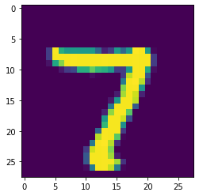

```python
plt.imshow(X[776][0]) # 777 observation, first channel
```

### 선형변환 대신에 2d convolution with windowsize=5

```python
c1=torch.nn.Conv2d(1,16,5) #입력채널=1: 흑백이니까, 아웃풋채널=16
```

```python
c1(X).shape
```

```
torch.Size([12396, 16, 24, 24])
```

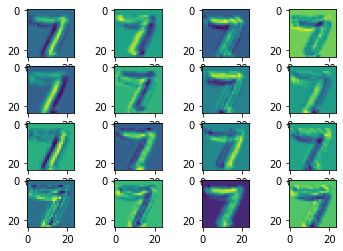

```python
fig, axs = plt.subplots(4,4)
k=0
for i in range(4):
    for j in range(4):
        axs[i,j].imshow(c1(X)[776][k].data)
        k=k+1
```

```python
fig.set_figheight(8)
fig.set_figwidth(8)
fig.tight_layout()
```

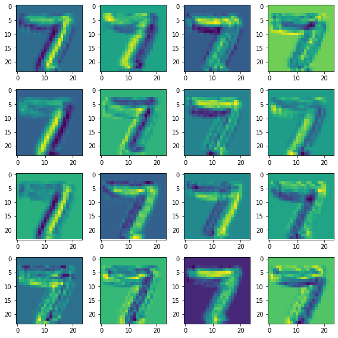

```python
fig
```

### ReLU() 대신에 MaxPool2d + ReLU

### maxpooling

```python
m1=torch.nn.MaxPool2d(2)
```

```python
c1(X).shape,m1(c1(X)).shape
```

```
(torch.Size([12396, 16, 24, 24]), torch.Size([12396, 16, 12, 12]))
```

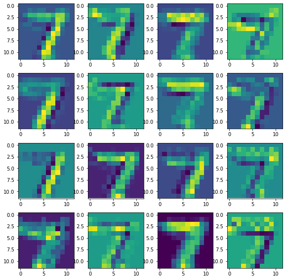

```python
fig, axs = plt.subplots(4,4)
k=0
for i in range(4):
    for j in range(4):
        axs[i,j].imshow(m1(c1(X))[776][k].data)
        k=k+1
fig.set_figheight(8)
fig.set_figwidth(8)
fig.tight_layout()
```

#### ReLU

```python
a1=nn.ReLU()
```

```python
c1(X).shape,m1(c1(X)).shape,a1(m1(c1(X))).shape
```

```
(torch.Size([12396, 16, 24, 24]),
 torch.Size([12396, 16, 12, 12]),
 torch.Size([12396, 16, 12, 12]))
```

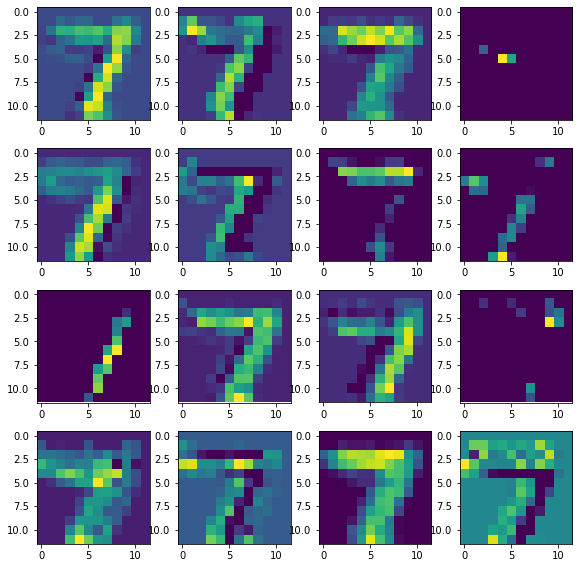

```python
fig, axs = plt.subplots(4,4)
k=0
for i in range(4):
    for j in range(4):
        axs[i,j].imshow(a1(m1(c1(X)))[776][k].data)
        k=k+1
fig.set_figheight(8)
fig.set_figwidth(8)
fig.tight_layout()
```

```python
torch.manual_seed(1)
_A=torch.randn(3,3)
_A
```

```
tensor([[ 0.6614,  0.2669,  0.0617],
        [ 0.6213, -0.4519, -0.1661],
        [-1.5228,  0.3817, -1.0276]])
```

```python
a1(_A)
```

```
tensor([[0.6614, 0.2669, 0.0617],
        [0.6213, 0.0000, 0.0000],
        [0.0000, 0.3817, 0.0000]])
```

### 이제 그냥 시그모이드에 태우자!!

`-` 현재상황

```python
a1(m1(c1(X))).shape
```

```
torch.Size([12396, 16, 12, 12])
```

`-` 펼치자

```python
a1(m1(c1(X))).reshape(12396,-1).shape
```

```
torch.Size([12396, 2304])
```

`-` 일단 2304 저 디멘젼을 1로 만들어야겠음

```python
l1=torch.nn.Linear(in_features=2304, out_features=1)
l1(a1(m1(c1(X))).reshape(12396,-1))
```

```
tensor([[-0.0361],
        [ 0.0838],
        [ 0.0316],
        ...,
        [ 0.0255],
        [ 0.0238],
        [-0.0393]], grad_fn=<AddmmBackward>)
```

`-` 시그모이드를 태우자.

```python
a2=torch.nn.Sigmoid()
a2(l1(a1(m1(c1(X))).reshape(12396,-1)))
```

```
tensor([[0.4910],
        [0.5209],
        [0.5079],
        ...,
        [0.5064],
        [0.5060],
        [0.4902]], grad_fn=<SigmoidBackward>)
```

### networks 설계

```python
net=nn.Sequential(
    c1, # 컨볼루션 (선형)
    m1, # 맥스풀링 (비선형) -- 효과? 나중에 다룰것: 이미지를 계층적으로 파악함
    a1, # 렐루 (비선형)


    a1(m1(c1(X))).reshape(12396,-1), ## 이걸어떻게구현하지?


    l1) # 선형변환
## 마지막의 a2는 생략한다. 손실함수에 이미 내장되어 있으므로
```

[output not shown]

```python
net=nn.Sequential(
    c1, # 컨볼루션 (선형)
    m1, # 맥스풀링 (비선형) -- 효과? 나중에 다룰것: 이미지를 계층적으로 파악함
    a1, # 렐루 (비선형)


#    a1(m1(c1(X))).reshape(12396,-1), ## 이걸어떻게구현하지?


    l1) # 선형변환
## 마지막의 a2는 생략한다. 손실함수에 이미 내장되어 있으므로.
```

결국 주석처리한 부분을 구현해야함.

`-` `c1`, `m1` ,`a1` ,`l1` 의 공통점?

- 무언가를 상속받는 클래스에서 생성된 인스턴스이다.
- forward 메소드가 있다.

`-` `c1`, `m1` ,`a1` ,`l1` 과 같은 레이어를 만드는 방법? (custom layer를 만드는 방법)

- torch.nn.Module을 상속받아서 클래스를 하나 만든다.
- forward 메소드를 정의한다. (다음층으로 리턴할 값)

```python
class Flatten(torch.nn.Module):
    def forward(self,x):
        return x.reshape(12396,-1)
```

```python
flatten=Flatten()
```

```python
a1(m1(c1(X))).shape
```

```
torch.Size([12396, 16, 12, 12])
```

```python
flatten(a1(m1(c1(X)))).shape
```

```
torch.Size([12396, 2304])
```

`-` 잘구현된것 같다! 이제 다시 네트워크를 만들자.

```python
net=nn.Sequential(
    c1, # 컨볼루션 (선형)
    m1, # 맥스풀링 (비선형) -- 효과? 나중에 다룰것: 이미지를 계층적으로 파악함
    a1, # 렐루 (비선형)
    flatten, # a1(m1(c1(X))).reshape(12396,-1), ## 이걸어떻게구현하지?
    l1) # 선형변환
## 마지막의 a2는 생략한다. 손실함수에 이미 내장되어 있으므로
```

`-` 손실함수와 옵티마이저 정의

```python
loss_fn=torch.nn.BCEWithLogitsLoss()
optimizer = torch.optim.Adam(net.parameters())
```

`-` step 1~4

```python
for epoc in range(200):
    ## 1
    yhat=net(X)
    ## 2
    loss= loss_fn(yhat,y)
    ## 3
    loss.backward()
    ## 4
    optimizer.step()
    net.zero_grad()
```

```python
plt.plot(y)
plt.plot(yhat.data,'.')
```

[output not shown]

```python
plt.plot(y)
plt.plot(a2(yhat.data),'.')
```

[output not shown]

```python
ypred= a2(yhat.data)>0.5
```

```python
sum(ypred==y)/12396
```

[output not shown]

```python
path.ls()
```

`-` 선형변환

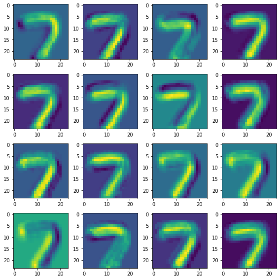

```python
fig, axs = plt.subplots(4,4)
k=0
for i in range(4):
    for j in range(4):
        axs[i,j].imshow(c1(X)[776][k].data)
        k=k+1
fig.set_figheight(8)
fig.set_figwidth(8)
fig.tight_layout()
```

일부 특징이 강화되어있음

`-` 맥스풀링

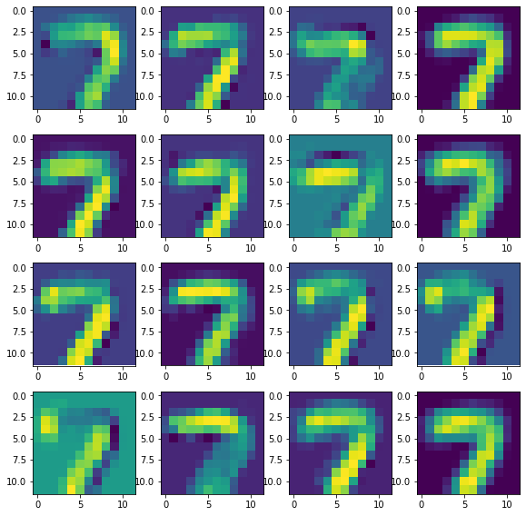

```python
fig, axs = plt.subplots(4,4)
k=0
for i in range(4):
    for j in range(4):
        axs[i,j].imshow(m1(c1(X))[776][k].data)
        k=k+1
fig.set_figheight(8)
fig.set_figwidth(8)
fig.tight_layout()
```

`-` 렐루

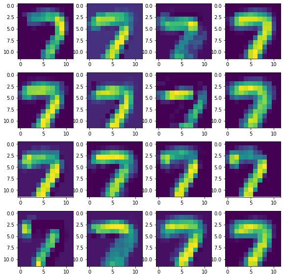

```python
fig, axs = plt.subplots(4,4)
k=0
for i in range(4):
    for j in range(4):
        axs[i,j].imshow(a1(m1(c1(X)))[776][k].data)
        k=k+1
fig.set_figheight(8)
fig.set_figwidth(8)
fig.tight_layout()
```